# Chapter 3 Data Pre-processing Exercises

```r
library(knitr)
library(kableExtra)
library(data.table)
library(ggplot2)
library(ggrepel)
library(caret)
library(mlbench)
library(AppliedPredictiveModeling)
library(e1071)
library(grid)
library(gtable)
library(RregressPkg)
library(RplotterPkg)
```

Author: Rick Dean

Article date: 2021-01-18

Abstract

The following notes/scripts/plots are inspired by Chapter 3 Data Pre-processing Exercises 3-1 of [Applied Predictive Modeling](http://appliedpredictivemodeling.com/) by Max Kuhn and Kjell Johnson.

## The Glass Dataset

### (a) Predictor variable visualization

Task: Set up Glass data set.

1. Initialize data.table with Glass data set:

```r
data(Glass, package = "mlbench")
glass_dt <- data.table::setDT(Glass)
glass_dt[,RI := round(RI,2)]
head(glass_dt)
```

```
##      RI    Na   Mg   Al    Si    K   Ca Ba   Fe Type
## 1: 1.52 13.64 4.49 1.10 71.78 0.06 8.75  0 0.00    1
## 2: 1.52 13.89 3.60 1.36 72.73 0.48 7.83  0 0.00    1
## 3: 1.52 13.53 3.55 1.54 72.99 0.39 7.78  0 0.00    1
## 4: 1.52 13.21 3.69 1.29 72.61 0.57 8.22  0 0.00    1
## 5: 1.52 13.27 3.62 1.24 73.08 0.55 8.07  0 0.00    1
## 6: 1.52 12.79 3.61 1.62 72.97 0.64 8.07  0 0.26    1
```

2. Add an *id* variable to the data.table:

```r
glass_dt[, id := rownames(Glass)]
data.table::setcolorder(glass_dt, neworder = c("id", "Type"))
```

Task: Plot the histograms of the predictor variables.

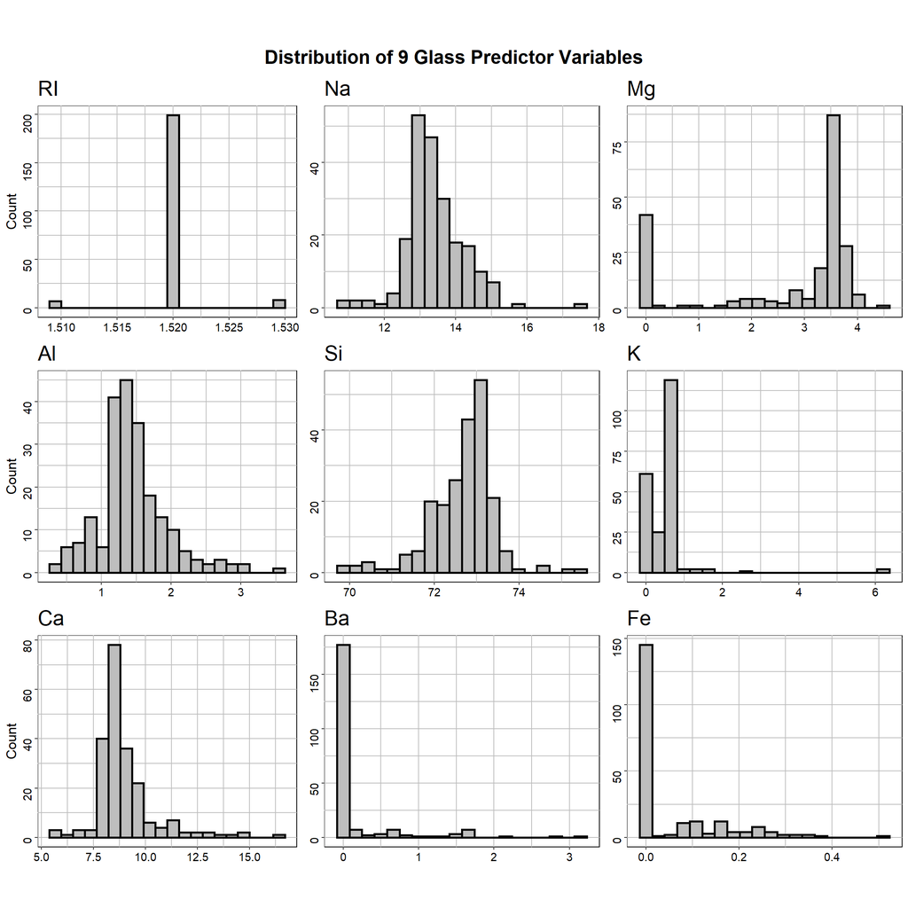

```r
glass_histo_plots <- RplotterPkg::multi_histogram_plot(
  df = glass_dt,
  variables = colnames(glass_dt)[3:11],
  columns = 3,
  row_height = 3.5,
  title = "Distribution of 9 Glass Predictor Variables"
)
```

The variable *RI* appears to have a constant value. Others appear to be severely skewed with *Ba* and *Fe* having values of 0.0.

Task: Show the correlations among all predictors with the exception of above three.

1. Calculate the correlations using `stats::cor()`:

```r
glass_dt <- glass_dt[, !c("id","Type","RI","Ba","Fe")]
glass_cor_mt <- stats::cor(glass_dt)
```

2. Plot the correlations in a heatmap:

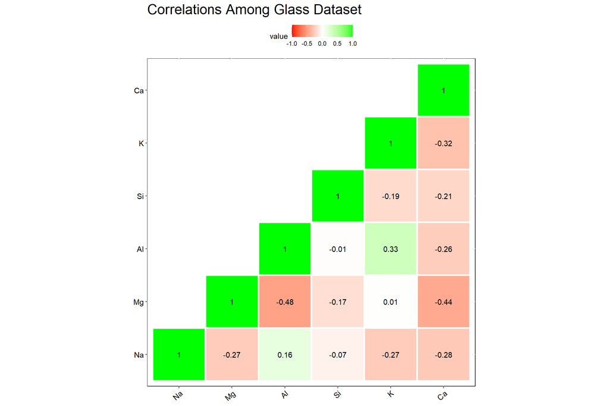

```r
RregressPkg::plot_correlations(
  corr = glass_cor_mt,
  title = "Correlations Among Glass Dataset",
  scale_colors = c("red", "green")
)
```

### (b) Outliers in the data

Task: There seem to be some notable correlations between *Al*/*Mg*, *Ca*/*Mg*, *K*/*Al* and *K*/*Ca*. Show a “matrix scatter” plot involving these variables.

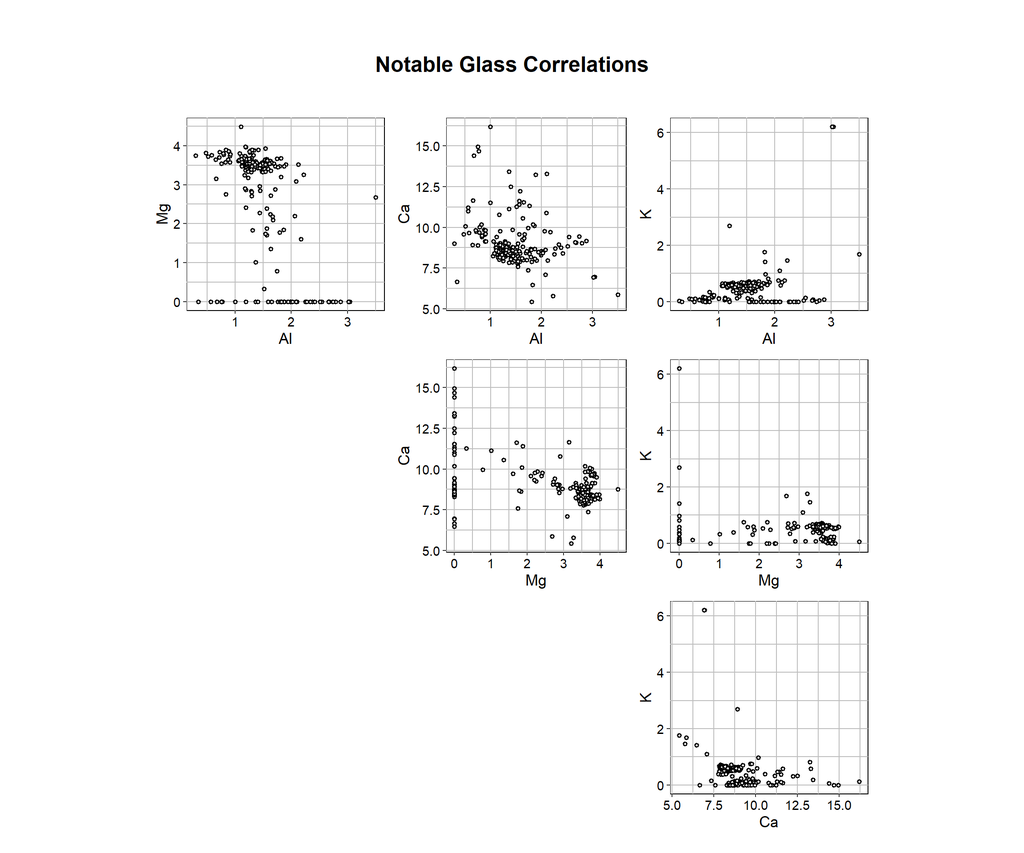

```r
RregressPkg::plot_matrix_scatter(
  df = glass_dt[, .(Al,Mg,Ca,K)],
  title = "Notable Glass Correlations",
  rot_y_tic_label = T
)
```

There appear to be outliers in nearly all the relationships.

Task: Compute the skewness for some of the variables.

```r
dt <- data.table::data.table(
  Na = e1071::skewness(glass_dt$Na),
  Mg = e1071::skewness(glass_dt$Mg),
  Al = e1071::skewness(glass_dt$Al),
  Si = e1071::skewness(glass_dt$Si),
  K = e1071::skewness(glass_dt$K),
  Ca = e1071::skewness(glass_dt$Ca)
)
RplotterPkg::create_table(
  x = dt,
  caption = "Skewness Measures for Glass Data"
)
```

Skewness Measures for Glass Data

| Na | Mg | Al | Si | K | Ca |
| --- | --- | --- | --- | --- | --- |
| 0.4478343 | -1.136452 | 0.8946104 | -0.7202392 | 6.460089 | 2.018446 |

Variables *K* and *Ca* are showing skewness as evident in the histograms.

### (c) Transformation of predictors

Task: Pre-process to scale, center, and address skewness of the predictors.

1. Create the pre-process:

```r
Glass_preProc <- caret::preProcess(glass_dt[, .(K, Ca)], method = c("BoxCox", "center", "scale"))
Glass_preProc
```

```
## Created from 214 samples and 2 variables
##
## Pre-processing:
##   - Box-Cox transformation (1)
##   - centered (2)
##   - ignored (0)
##   - scaled (2)
##
## Lambda estimates for Box-Cox transformation:
## -1.1
```

2. Apply the pre-process:

```r
glass_dt <- data.table::setDT(stats::predict(Glass_preProc, glass_dt))
```

Task: Re-plot the predictor histograms with the pre-processed values.

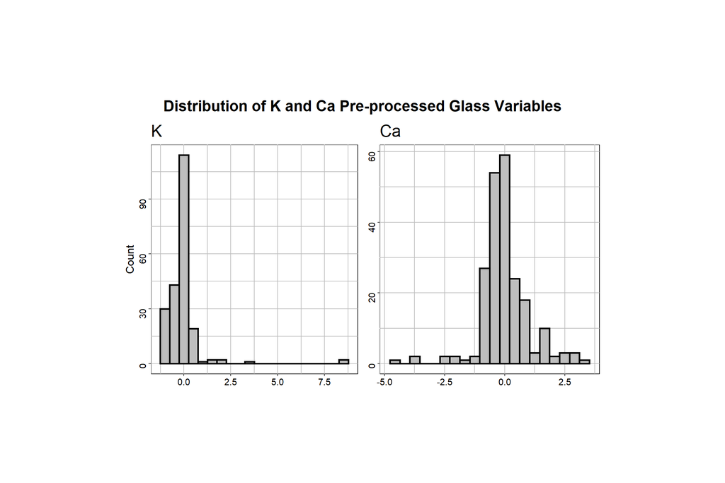

```r
RplotterPkg::multi_histogram_plot(
  df = glass_dt,
  variables = c("K", "Ca"),
  columns = 2,
  row_height = 4.5,
  title = "Distribution of K and Ca Pre-processed Glass Variables"
)
```

Task: Create a box plot of the pre-processed predictor observations to identify possible outliers.

1. Scale *glass_dt* and create a “long” version of it:

```r
glass_scaled_dt <- data.table::as.data.table(scale(glass_dt))
glass_scaled_dt <- glass_scaled_dt[, id := Glass$id]
glass_long_dt <- data.table::melt(glass_scaled_dt, id.vars = "id", measure.vars = c("Na", "Mg", "Al", "Si", "K", "Ca"))
head(glass_long_dt)
```

```
##    id variable      value
## 1:  1       Na  0.2842867
## 2:  2       Na  0.5904328
## 3:  3       Na  0.1495824
## 4:  4       Na -0.2422846
## 5:  5       Na -0.1688095
## 6:  6       Na -0.7566101
```

2. Create the box plot with outlier observations labeled with their *id* number:

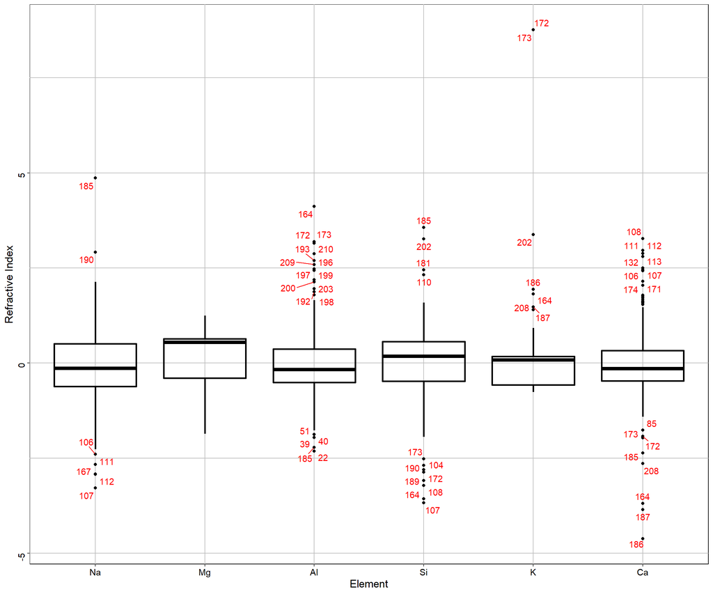

```r
RplotterPkg::create_box_plot(
  df = glass_long_dt,
  aes_x = "variable",
  aes_y = "value",
  x_title = "Element",
  y_title = "Refractive Index",
  show_outliers = T,
  label_outlier_var = "id",
  label_outlier_color = "red"
)
```